# Vis_dat Tmin

Guido

2020-10-24

I grafici che seguono rappresentano le serie delle medie annuali di temperatura massima/minima. Il grigio corrispondi a valori NA (mancanti) mentrel’arancione segnala la presenza di un dato annuale non NA. **ATTENZIONE**: i valori medi annuali sono stati calcolati senza seguire la regoladel 3/5 o 4/10 del WMO. Pertanto, i grafici che seguono danno solo un’idea parziale della lunghezza delle serie dal 1961 al 2018.

**NOTA BENE: qui mancano due stazioni identificate dal codice che inizia per “12”. Rivedere come mai queste stazioni non compaiono nel dataset dei dati dell’Emilia-Romagna 1961-2018.**

# Visualizzazione generale dello stato dei dati

Il grafico che segue rappresenta tutto il dataset dell’Emilia Romagna.

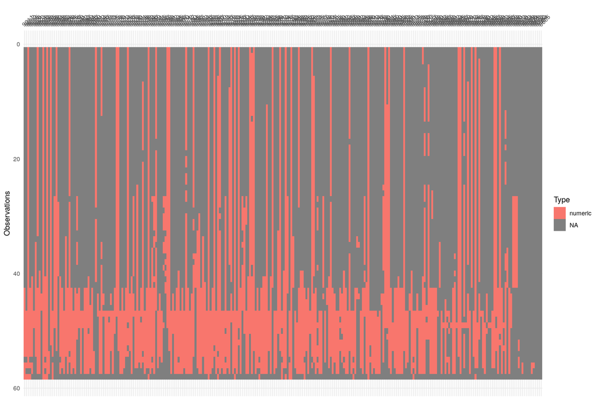

# Visualizzazione generale dello stato dei dati delle serie omogeneizzate

Il grafico che segue rappresenta solo le serie dell’Emilia Romagna utilizzate fino al 2020 per il rapporto “Gli Indicatori del clima in Italia”.

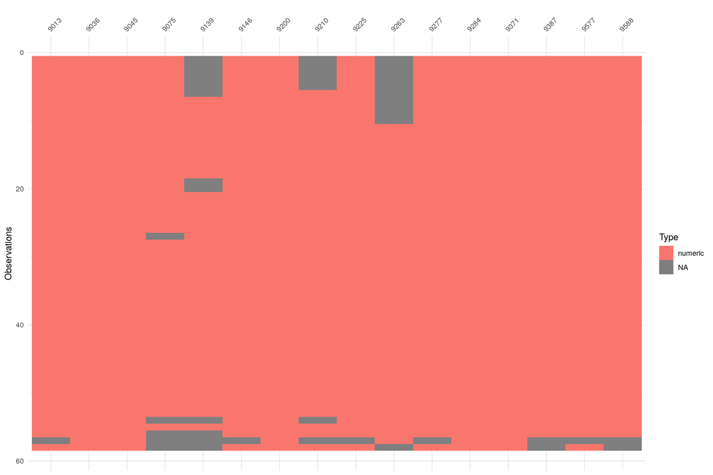

Anagrafica delle stazioni omogeneizzate.

|  | ID_STAZ | NOME | LON | LAT | QUOTA | COD_UTENTE |
| --- | --- | --- | --- | --- | --- | --- |
| 1 | 9013 | ALFONSINE | 12.04450 | 44.49303 | 7 | 08ALFONSINE |
| 2 | 9036 | BEDONIA | 9.62672 | 44.50747 | 527 | 08BEDONIA |
| 3 | 9045 | BOBBIO | 9.38367 | 44.75512 | 364 | 08BOBBIO |
| 4 | 9075 | CAMPIGNA | 11.74716 | 43.87222 | 1034 | 08CAMPIGNA |
| 5 | 9139 | COTTEDEMEC | 11.16929 | 44.10963 | 838 | 08COTTEDEMEC |
| 6 | 9146 | FAENZA | 11.88623 | 44.29127 | 34 | 08FAENZA |
| 7 | 9200 | LIGONCHIO | 10.34466 | 44.31683 | 803 | 08LIGONCHIO |
| 8 | 9210 | MARINADIRAVENNA | 12.28385 | 44.49094 | NA | 08MARINADIRAVENNA |
| 9 | 9225 | MODIGLIANA | 11.79617 | 44.15559 | 240 | 08MODIGLIANA |
| 10 | 9263 | OSPITALETTO | 10.31666 | 44.29697 | 1272 | 08OSPITALETTO |
| 11 | 9277 | PAVULLO | 10.82824 | 44.31958 | 687 | 08PAVULLO |
| 12 | 9284 | PIANDELAGOTTI | 10.51632 | 44.23714 | 1228 | 08PIANDELAGOTTI |
| 13 | 9371 | SESTOLA | 10.76870 | 44.23213 | 1005 | 08SESTOLA |
| 14 | 9387 | SUVIANA | 11.04298 | 44.13445 | 479 | 08SUVIANA |
| 15 | 9577 | Novafeltria Marecchia | 12.29380 | 43.89280 | 263 | 08NOVAFELTRIA |
| 16 | 9588 | San Cassiano Lamone | 11.69360 | 44.15120 | 437 | 08SNCASSIANO |

# Visualizzazione generale dello stato dei dati delle serie NON omogeneizzate

Vi sono delle serie di temperatura non prese in esame nei precedenti rapporti “Gli Indicatori del Clima” che pero’ potrebbero tornarci utili se si rendessero meno restrittivi i criteri di completezza, lunghezza e continuita’? Visualizziamo le serie del dataset dell’Emilia Romagna con almeno con 40 dati annuali non NA.

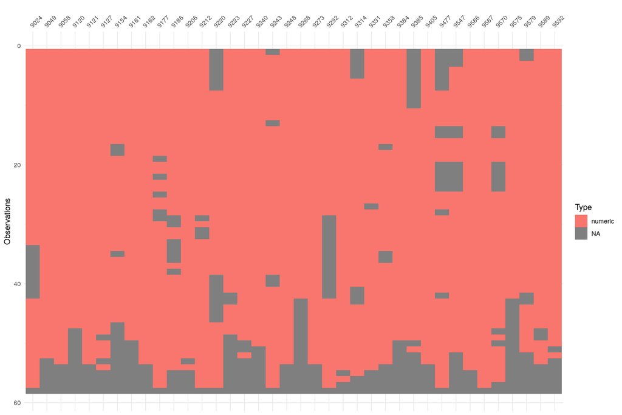

La tabella che segue contiene l’anagrafica delle stazioni del grafico sopra.

|  | ID_STAZ | NOME | LON | LAT | QUOTA | COD_UTENTE |
| --- | --- | --- | --- | --- | --- | --- |
| 1 | 9024 | BAISO | 10.60569 | 44.49908 | 504 | 08BAISO |
| 2 | 9049 | BOLOGNAUFFID | 11.34614 | 44.49990 | 45 | 08BOLOGNAUFFID |
| 3 | 9058 | BOSCHIAVETO | 9.41993 | 44.58591 | 757 | 08BOSCHIAVETO |
| 4 | 9120 | CESENA | 12.21848 | 44.14397 | 34 | 08CESENA |
| 5 | 9121 | CESENATICO | 12.39741 | 44.20713 | 1 | 08CESENATICO |
| 6 | 9127 | CODIGORO | 12.09771 | 44.83513 | 2 | 08CODIGORO |
| 7 | 9154 | FERRARA | 11.62098 | 44.83242 | 9 | 08FERRARA |
| 8 | 9161 | FONTANALUCCIA | 10.51528 | 44.27889 | 766 | 08FONTANALUCCIA |
| 9 | 9162 | FORLI | 12.05551 | 44.21859 | 29 | 08FORLI |
| 10 | 9177 | GUAGNINO | 12.21159 | 44.68842 | 3 | 08GUAGNINO |
| 11 | 9186 | ISOLAPALANZANO | 10.16215 | 44.42838 | 655 | 08ISOLAPALANZANO |
| 12 | 9206 | MALALBERGO | 11.52905 | 44.71847 | 13 | 08MALALBERGO |
| 13 | 9212 | MARRA | 10.04744 | 44.47344 | 670 | 08MARRA |
| 14 | 9220 | MIRANDOLAAGRO | 11.00854 | 44.88308 | 18 | 08MIRANDOLAAGRO |
| 15 | 9223 | MODENAISA | 10.93430 | 44.64802 | 33 | 08MODENAISA |
| 16 | 9227 | MOLATODIGA | 9.28802 | 44.90789 | 401 | 08MOLATODIGA |
| 17 | 9240 | MONTEOMBRARO | 11.00490 | 44.37943 | 684 | 08MONTEOMBRARO |
| 18 | 9243 | MONTESE | 10.94203 | 44.27693 | 830 | 08MONTESE |
| 19 | 9248 | MONZUNO | 11.27351 | 44.27663 | 587 | 08MONZUNO |
| 20 | 9268 | OZOLADIGA | 10.36861 | 44.28750 | 1518 | 08OZOLADIGA |
| 21 | 9273 | PARMAUNIVERSITA | 10.31500 | 44.80457 | 55 | 08PARMAUNIVERSITA |
| 22 | 9292 | POLINAGO | 10.72975 | 44.34366 | 741 | 08POLINAGO |
| 23 | 9312 | QUARTODIGA | 12.08636 | 43.89069 | 387 | 08QUARTODIGA |
| 24 | 9314 | RAMIOLA | 10.09231 | 44.69726 | 137 | 08RAMIOLA |
| 25 | 9331 | ROCCASCASCIANO2 | 11.84195 | 44.05349 | 310 | 08ROCCASCASCIANO2 |
| 26 | 9358 | SARMATO | 9.50273 | 45.08400 | 53 | 08SARMATO |
| 27 | 9384 | STRETTARA | 10.70134 | 44.24905 | 972 | 08STRETTARA |
| 28 | 9385 | STRINABECCO | 9.48956 | 44.45084 | 929 | 08STRINABECCO |
| 29 | 9405 | VERGHERETO | 12.00440 | 43.79521 | 844 | 08VERGHERETO |
| 30 | 9477 | PRACCHIA | 10.90770 | 44.05680 | 660 | 08PRACCHIA |
| 31 | 9547 | Acquerino Reno-Limonta | 11.01950 | 44.01170 | 859 | 08ACQUERINO |
| 32 | 9566 | Imola meccanica Reno-Santerno | 11.71480 | 44.34850 | 44 | 08IMOLAMEC |
| 33 | 9567 | Lago Paduli | 10.14050 | 44.34850 | 1181 | 08LAGOPADULI |
| 34 | 9570 | Maresca Reno | 10.85060 | 44.06030 | 1139 | 08MARESCA |
| 35 | 9575 | Montecapraro | 9.15520 | 44.73610 | 853 | 08MONTECAPRARO |
| 36 | 9579 | POGGIORUSCO ETG Pianura Secchia-Panaro | 11.12790 | 44.97040 | 14 | 08POGGIORUSCO |
| 37 | 9589 | San Lazzaro Alberoni Trebbia | 9.72700 | 45.03780 | 53 | 08SNLAZZAROALB |
| 38 | 9592 | San Michele Centrale Panaro-Scoltenna | 10.62830 | 44.19740 | 886 | 08SNMICHELECLE |